# KNN Classification on the Iris Dataset

Joshua Agbroko

# **Introduction**

The **Iris Dataset** is a classic dataset used in machine learning. In this project, we will use the **K_Nearest Neighbours(KNN)** algorithm to classsify iris species based on sepal and petal measurements.

Key steps in this analysis:

- Data Preprocessing & Normalization
- Hyperparameter Tuning with Cross-Validation
- Model Evaluation & Visualization
- Summary of Findings

# **Loading Libraries & Data**

```r
# loading necessary libraries
library(tidyverse)
library(caret)
library(kknn)
library(knitr)

# loading Iris dataset
data(iris)
head(iris) %>% kable()
```

| Sepal.Length | Sepal.Width | Petal.Length | Petal.Width | Species |
| --- | --- | --- | --- | --- |
| 5.1 | 3.5 | 1.4 | 0.2 | setosa |
| 4.9 | 3.0 | 1.4 | 0.2 | setosa |
| 4.7 | 3.2 | 1.3 | 0.2 | setosa |
| 4.6 | 3.1 | 1.5 | 0.2 | setosa |
| 5.0 | 3.6 | 1.4 | 0.2 | setosa |
| 5.4 | 3.9 | 1.7 | 0.4 | setosa |

# **Data Preprocessing**

```r
# ensuring Species is a factor
iris$Species <- as.factor(iris$Species)
```

```r
# Min-max normalization
normalize <- function(x){
  (x - min(x)) / (max(x) - min(x))
}

iris_norm <- iris %>%
  mutate(across(where(is.numeric), normalize))

head(iris_norm) %>% kable()
```

| Sepal.Length | Sepal.Width | Petal.Length | Petal.Width | Species |
| --- | --- | --- | --- | --- |
| 0.2222222 | 0.6250000 | 0.0677966 | 0.0416667 | setosa |
| 0.1666667 | 0.4166667 | 0.0677966 | 0.0416667 | setosa |
| 0.1111111 | 0.5000000 | 0.0508475 | 0.0416667 | setosa |
| 0.0833333 | 0.4583333 | 0.0847458 | 0.0416667 | setosa |
| 0.1944444 | 0.6666667 | 0.0677966 | 0.0416667 | setosa |
| 0.3055556 | 0.7916667 | 0.1186441 | 0.1250000 | setosa |

# **Splitting Data into Training & Test Sets**

I’ll use 80% of the data for training and 20% for testing while preserving class imbalance.

```r
set.seed(123)
train_index <- createDataPartition(iris_norm$Species, p = 0.8, list = FALSE)

train_data <- iris_norm[train_index, ]
test_data <- iris_norm[-train_index, ]
```

# **Training KNN Model with Hyperparameter Tuning**

I’ll use a 5-fold cross-validation to find the optimal number of neighbours(k)

```r
# Defining training control with cross-validation
train_control <- trainControl(method = "cv", number = 5)

# Defining grid of k values(only odd to avoid ties)
grid <- expand.grid(
  kmax = seq(1, 15, by = 2),               # maximum neighbours
  distance = 2,                 # euclidean distance
  kernel = "optimal")           # Weighting function

# Train model
set.seed(123)
knn_model <- train(
  Species ~ .,
  data = train_data,
  method = "kknn",
  tuneGrid = grid,
  trControl = train_control
)

# Display best k value
knn_model$bestTune %>% kable()
```

|  | kmax | distance | kernel |
| --- | --- | --- | --- |
| 7 | 13 | 2 | optimal |

# **Model Performance**

I evaluate the trained model using accuracy and a confusion matrix.

```r
# Predicitonon test data
predictions <- predict(knn_model, test_data)

# Generating the confusion matrix
conf_matrix <- confusionMatrix(predictions, test_data$Species)

# Print
conf_matrix
```

```
## Confusion Matrix and Statistics
##
##             Reference
## Prediction   setosa versicolor virginica
##   setosa         10          0         0
##   versicolor      0          9         2
##   virginica       0          1         8
##
## Overall Statistics
##
##                Accuracy : 0.9
##                  95% CI : (0.7347, 0.9789)
##     No Information Rate : 0.3333
##     P-Value [Acc > NIR] : 1.665e-10
##
##                   Kappa : 0.85
##
##  Mcnemar's Test P-Value : NA
##
## Statistics by Class:
##
##                      Class: setosa Class: versicolor Class: virginica
## Sensitivity                 1.0000            0.9000           0.8000
## Specificity                 1.0000            0.9000           0.9500
## Pos Pred Value              1.0000            0.8182           0.8889
## Neg Pred Value              1.0000            0.9474           0.9048
## Prevalence                  0.3333            0.3333           0.3333
## Detection Rate              0.3333            0.3000           0.2667
## Detection Prevalence        0.3333            0.3667           0.3000
## Balanced Accuracy           1.0000            0.9000           0.8750
```

# **Visualizing KNN Accuracy**

Plotting accuracy scores for different values of k from cross-validation

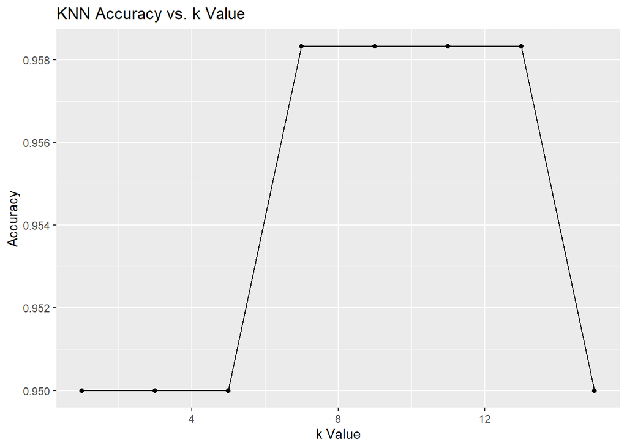

```r
ggplot(knn_model) +
  labs(title = "KNN Accuracy vs. k Value", x = "k Value", y = "Accuracy")
```

# **Conclusion**

## Findings

- The best ‘k’ value for our model, determined via cross-validation, was 13, 2, optimal.
- The model achieved an overall accuracy of 90% on the test dataset.
- The confusion matrix showed that **most misclassification occurred between similar species**, particularly in cases where feature differences were minimal.

## Final Thoughts

KNN proved to be strong classifier for the **Iris dataset**, achieving high accuracy with minimal tuning. However further improvements, such as using a different feature transformation or more advanced hyperparameter tuning, could enhance performance further.